# MAD – Data Analysis & Biostatistics in R

Chapter 9 – Tidy Data – Make Them Ready for Analysis

James R. Hunter, Ph.D.

DIPA, EPM, UNIFESP

2020-09-05

Up to now, most of what we have been discussing falls in the realm of computer science more than statistics. Now that we have know how to bring data into R, we will consider the data themselves and undertake some preliminary analyses to make them ready for the larger analysis that will follow.

# 1 First Step - What is the Current State of the Data?

By looking at a summary of the data as we have imported it, we can decide on a list of cleaning tasks we need to complete. Every data set is different and will need its own list of tasks. However, there are some general principles that we can follow where problems usually lie. We will focus on those types of problems here and various ways we can improve the quality of our data. Equally important, we will discover those variables and cases that will need continuing attention as we proceed into the data analysis phase of our project.

## 1.1 Print a Summary of the Data Frame/Tibble

There are two complementary ways we should look at the data. First, we should always execute `glimpse()` or `str()` to see the overall *structure* of the data frame: what variables R treats as what class, how many cases and how many variables there are, etc.

This can rapidly be done with either of these functions. Here I will use `glimpse()` to look at the Einstein Hospital sorological tests we imported in the last chapter. I will first enable the `tidyverse` package

```r
library(tidyverse)
einstein_soro <- read_csv(here::here("einstein_soro_tests.csv"), col_types = "ccccccfncc", na = c("Não reagente", "NULL", "NA"))

glimpse(einstein_soro)
```

```
## Rows: 99
## Columns: 10
## $ pacid      <chr> "b6d668e4f818f7b3643ed593b8fb902bf9d2501e", "a090625661c...
## $ dt_collect <chr> "28/05/2020", "11/05/2020", "16/06/2020", "10/06/2020", ...
## $ analysis   <chr> "IgM, COVID19", "IgG, COVID19", "IgG, COVID19", "COVID I...
## $ result     <chr> "0.74", "0.03", "0.02", "Não reagente", "0.47", "0.9", "...
## $ unit       <chr> "AU/ml", "AU/ml", "AU/ml", NA, "AU/ml", "AU/ml", NA, "AU...
## $ reference  <chr> "<=0.90", "<=0.90", "<=0.90", "", "<=0.90", "<=0.90", ""...
## $ sex        <fct> male, female, female, male, female, female, female, male...
## $ birth_yr   <dbl> 1989, 1975, 1997, 2006, 1983, 1963, 1988, 1971, 1968, 19...
## $ uf         <chr> "SP", "GO", "SP", "SP", "SP", "SP", "SP", "SP", "SP", "S...
## $ city       <chr> "SAO PAULO", NA, "SAO PAULO", "SAO PAULO", "SAO PAULO", ...
```

Next, I would like to look at the data in some more detail. One of the best ways to do that is to use the `dfSummary()` from the `summarytools` package, which we have installed as part of the set of packages in Chapter 1. This function will give us a short summary of each variable in the data set with the presentation keyed to the class of variable involved. `dfSummary()` has many options. The only option I normally leave out is the graph column, which I find does not contribute much to the information I need, is visually irritating and occupies a lot of precious space. To remove it (or any other option shown in the Help screen), just set it to `FALSE` like this: `graph.col = FALSE`.

[figure not shown]

```r
library(summarytools)
dfSummary(einstein_soro, graph.col = FALSE)
```

```
## Data Frame Summary
## einstein_soro
## Dimensions: 99 x 10
## Duplicates: 0
##
## -----------------------------------------------------------------------------------------------
## No   Variable      Stats / Values                    Freqs (% of Valid)   Valid      Missing
## ---- ------------- --------------------------------- -------------------- ---------- ----------
## 1    pacid         1. 373a2ae841153ee5f4d86c245       2 ( 2.0%)           99         0
##      [character]   2. 95ecc1410a0f8abfde332e73d       2 ( 2.0%)           (100%)     (0%)
##                    3. 0a67cd063da4bfade9be8e0e4       1 ( 1.0%)
##                    4. 0d4c2100337f05f197256160d       1 ( 1.0%)
##                    5. 0f68cd676ae5b106902b8a4b9       1 ( 1.0%)
##                    6. 1226637f4eb61db0f06c6fac2       1 ( 1.0%)
##                    7. 161f5d5b585c29048f523bd61       1 ( 1.0%)
##                    8. 19210bb9bc58276bc7daf9fb9       1 ( 1.0%)
##                    9. 1cbf74c501b4c182e8a0475fc       1 ( 1.0%)
##                    10. 200dbeeda1df13240200a8996      1 ( 1.0%)
##                    [ 87 others ]                     87 (87.9%)
##
## 2    dt_collect    1. 05/06/2020                      6 ( 6.1%)           99         0
##      [character]   2. 04/06/2020                      5 ( 5.1%)           (100%)     (0%)
##                    3. 08/06/2020                      4 ( 4.0%)
##                    4. 10/06/2020                      4 ( 4.0%)
##                    5. 12/05/2020                      4 ( 4.0%)
##                    6. 14/05/2020                      4 ( 4.0%)
##                    7. 19/05/2020                      4 ( 4.0%)
##                    8. 21/05/2020                      4 ( 4.0%)
##                    9. 30/04/2020                      4 ( 4.0%)
##                    10. 02/06/2020                     3 ( 3.0%)
##                    [ 36 others ]                     57 (57.6%)
##
## 3    analysis      1. COVID IgG Interp               22 (22.2%)           99         0
##      [character]   2. COVID IgM Interp               22 (22.2%)           (100%)     (0%)
##                    3. IgG, COVID19                   29 (29.3%)
##                    4. IgM, COVID19                   26 (26.3%)
##
## 4    result        1. Não reagente                   39 (39.4%)           99         0
##      [character]   2. 0.02                            7 ( 7.1%)           (100%)     (0%)
##                    3. 0.54                            4 ( 4.0%)
```

[output cut: 19 more lines]

```
## 8    birth_yr      Mean (sd) : 1978.8 (16.3)         47 distinct values   96         3
##      [numeric]     min < med < max:                                       (96.97%)   (3.03%)
##                    1933 < 1979.5 < 2020
##                    IQR (CV) : 21.2 (0)
##
## 9    uf            1. GO                              1 ( 1.0%)           99         0
##      [character]   2. MS                              1 ( 1.0%)           (100%)     (0%)
##                    3. SP                             97 (98.0%)
##
## 10   city          1. BARUERI                         2 ( 2.3%)           88         11
##      [character]   2. JUNDIAI                         6 ( 6.8%)           (88.89%)   (11.11%)
##                    3. SANTANA DE PARNAIBA             2 ( 2.3%)
##                    4. SAO PAULO                      77 (87.5%)
##                    5. SOROCABA                        1 ( 1.1%)
## -----------------------------------------------------------------------------------------------
```

After giving some simple statistics on the overall data frame, `dfSummary()` goes variable by variable and shows a selection of the values that the variable takes on most frequently, the frequency with which it takes on each of these values, the number and percentage of valid cases and the number and percentage of cases that have `NA` for that variable. As we go down the variables, there are a number of issues that you should consider as the data analyst.

### 1.1.1 Review of Variables in Initial Exploration

I have previously mentioned the non-standard format of `dt_collect` which forced the variable into the character class. There are a number of functions that will allow us to transform this into a Date class variable on which we can perform date arithmetic. We use the `lubridate` package from the Tidyverse set of packages to accomplish this. I have found these the easiest to use and remember to accomplish this task.

The next problem arises in the next variable `analysis`. The results have two different ways to report the IgG and IgM antibodies. Either they report “COVID IgG Interp” or “IgG, COVID19”. The same pattern exists for IgM. These could be two distinct analyses that were done on IgG or they could be the same. You will need to check with the researchers which this really is. If they are two different ways of noting the same analysis, we will need to combine them prior to using them in any analysis we prepare.

I identified the problem of the “Nao reagente” text in the `result` variable, but here we see that it is not the only non-numeric value. Before proceeding to the analysis, we will need to decide how to treat each of these non-numeric values.

The `unit` variable only has one value, “AU/ml”. It is not useful in the analysis since it has no variation. We should remove it, which we can do in a number of ways. However, we will use `remove_constant()` from the `janitor` package to show you a useful tool for dealing with this type of problem.

The `reference` variable has three values: “<= 0.90”, “Nao reagente”, or an empty string. You will need to decide how you want to use these values. It may be that you will determine the reference levels for the antibodies from an external source. If this is so, the variable is superfluous and can be removed.

The `sex` variable has already been transformed into a factor variable and needs no further changes.

The `birth_yr` variable is the only numeric variable we are encountering here. You can see in the presentation of this variable that it provides a number of basic statistical measures for the year including mean and standard deviation as well as the minimum value, median value and maximum value. They also report the IQR (Interquartile Range), which is the 75th percentile less the 25th percentile. Finally, the give you a rough coefficient of variation (“CV”), which is another measure of the spread of a numeric variable (calculated as the standard deviation divided by the mean).

The final variable shows the `uf` (state) in which the patients reside. You will note that 97 of the 99 cases reside in Sao Paulo. This makes total sense since Albert Einstein Hospital is located there. If you decide you want to limit your conclusions to Sao Paulo, then perhaps during this phase or during the analytic phase, you will want to eliminate the two non-Sao Paulo cases.

## 1.2 Cleaning the Variable Names

The second general step we take before turning to the individual variables we want to study is to clean the names so they will not present any problems in R. We will use `clean_names()` from the `janitor` package to do this. It handles problematic variables names well, handles foreign accents (by removing them), keeps two columns from having the same name and coverts non-text characters to text, among other automatic transformations.

As it happens, our data set already has a set of variable names that fit the `clean_names()` standard, so I will demonstrate this on an invented set of variable names.[^1]

The following code will list the names that we will let `clean_names()` work on and we will see the results after the transformations.

```r
test_df <- as.data.frame(matrix(ncol = 6))
names(test_df) <- c("firstName", "$abc@!*", "% successful (2009)",
                    "REPEAT VALUE", "REPEAT VALUE", "")
test_df
```

```
##   firstName $abc@!* % successful (2009) REPEAT VALUE REPEAT VALUE
## 1        NA      NA                  NA           NA           NA NA
```

```r
# apply clean_names()

test_df <- janitor::clean_names(test_df)

test_df
```

```
##   first_name abc percent_successful_2009 repeat_value repeat_value_2  x
## 1         NA  NA                      NA           NA             NA NA
```

You can see that all of the six variables were modified and put into easier to understand R form. First, the camel case version of “firstName” was changed to snake case (“first_name”), the default for `clean_names()`. The second variable, whose original names contained accents and punctuation marks ("$abc@!*“) was changed to a simple”abc“. The percentage sign and parentheses in the third variable as well as the spaces (”% successful (2009)“) were converted to a snake_case name without spaces or special symbols (”percent_successful_2009“). The two following variables had the same original name,”REPEAT VALUE“. `clean_names()` made them both lower case removed the space between them. It also added a”_2" to the second of the variables to make sure it was distinguished from the first. The final variable had no name. Because R variables need names so they can be referred to in functions, `clean_names()` assigned the name “X” to the variable. While `clean_names()` can make many replacements using its rules, it cannot guess what the content of the column should be called. Perhaps in the future ….

### 1.2.1 Assigning Your Own Names to Variables

If you want to redo the names on your own, you can use the function that I used to create the list of crazy names first: `names()`. The format of the function is

```
names(test_df) <- c("first_name", "last_name", "percent_successful_2009",
    "value_1", "value_2", "standard")
```

`names(df) <-` assigns the vector of names on the right side of the assignment to the data frame or tibble in the parentheses on the left side.

# 2 Munging the Variables

“Munge” is the accepted geeky term for manipulate variables and data. We will now go through the variables identified above and apply the appropriate munging technique to make the variables ready for analysis. After that, we will make sure that the data is tidy, in the Tidyverse sense of the term.

## 2.1 Convert Dates from Text to Date Format

### 2.1.1 Parsing Dates

As I indicated above, we need to transform the `dt_collect` variable above from text to the `date` class so we can calculate time intervals and other quantitative measure of time. We will use the translation functions from the `lubridate` package. These functions take a text formatted date field, examine its components and apply the function chosen to bring the date into a date format. Before choosing the correct function, you need to determine the order in which the day, month and year appear. Looking at the `dt_collect` variable, you see that the day comes first, followed by the month, followed by the year. This is the standard Brazilian manner of writing a date, “dd/mm/yyyy”. The functions use the combination of the initial letters of the day, month and year in the correct order. So, the function we would use is `dmy()`. If we were transforming an American standard date, “mm/dd/yyyy”, we instead would use the function `mdy()`. **VSS:** All these formats ignore the separator character (“/” in this case). Let us see these examples in R code.

```r
library(lubridate)  # need to load as it is not loaded as part of tidyverse
br_text <- "28/05/2020"
(br_date <- dmy(br_text)) # remember: parentheses outside a function print it to screen
```

```
## [1] "2020-05-28"
```

```r
us_text <- "05-28-2020"
(us_date <- mdy(us_text))
```

```
## [1] "2020-05-28"
```

Although the texts of both dates are different, they refer to the same date as the xx_date variables show.

These are not the only options. The ISO standard date is in year-month-date, what they refer to as most to least significant elements. In this case, we would use the `ymd()` function to convert the date. You can see that the result of the date transformation functions appear in the ISO format.

At this point, we can find out how long it has been since the `br_date` we created above. `lubridate` has a function `today()`, which will give us the current date. Base R has a similar function, `Sys.Date()` that accomplishes the same task if you want to use that. To find the difference in time between two dates, one only needs to subtract one from the other as in the next block:

```r
today()
```

```
## [1] "2020-09-05"
```

```r
br_date
```

```
## [1] "2020-05-28"
```

```r
today() - br_date
```

```
## Time difference of 100 days
```

### 2.1.2 Changing (Mutate) the `dt_collect` Variable

Now that we know how to transform the date, we need to put the new values in place of the text version in the `dt_collect` variable in `einstein_soro`. To change the values of a variable in an existing data frame or to add a new variable, we use the `mutate()` function of the `dplyr` package. `dplyr` is one of the central packages of the Tidyverse. It contains the functions that enable us to manipulate variables. It uses other functions of other Tidyverse packages, like `lubridate`, `tidyr`, `stringr` and `forcats` to provide specific variable munging capabilities.

### 2.1.3 The “Pipe”

We frequently need to join functions together to create a compound command. For example, suppose we would like to perform a hypothetical sequence of operations on a hypothetical data frame x using hypothetical functions `f()`, `g()`, and `h()`:[^2]

- Take `x` then
- Use `x` as an input to a function `f()` then
- Use the output of `f(x)` as an input to a function `g()` then
- Use the output of `g(f(x))` as an input to a function `h()`

One way to achieve this sequence of operations is by using nesting parentheses as follows:

```
h(g(f(x)))
```

This code is not especially easy to read although it is easier than many of the functions we would create in base R. However, using the “pipe” operator (“%>%”), we can join together the various steps in the compound function in a more readable form. The pipe takes what is on the left side of the operator and makes that the first argument of the right side of the operator.[^3] In effect, you can think of the pipe as meaning “and then”. Using the pipe, we could rewrite the above function as

```
x %>%
  f() %>%
  g() %>%
  h()
```

You could read this sequence of actions, this compound function, as:

1. Take `x` then
2. Use this output as the input to the next function `f()` then
3. Use this output as the input to the next function `g()` then
4. Use this output as the input to the next function `h()`

### 2.1.4 Mutating `dt_collect`

The `mutate()` function takes the data frame or tibble you are modifying as the first argument and modifies it in the second argument in the form of an assignment, this time explicitly using an equals sign rather than the “<-” sign we normally use for assignment. If we use a new variable name on the left side of the “=”, then this variable will become a new variable in the data frame. There are a wide variety of functions and operators we can use to make the transformation we need. The following figure shows those listed on the Data Transformation with dplyr Cheat Sheet.

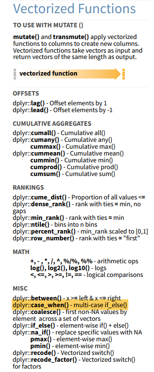

When you modify existing variables, as we are doing with `dt_collect`, you will be overwriting the existing values. As a result, it usually advisable to create a new data frame so that the original is always available if you make a mistake and need the original data (in this case, the text version of the date). If you are creating a new variable, creating a new data frame is not necessary as you have not wiped out anything. So, a rule of thumb: **VSS**: if overwriting, do it in a new data frame; if creating a new variable, continue working with existing data frame.

The steps we will follow to accomplish this change are

1. to establish the name of the revised data frame then
2. assign to it the data from the old version then
3. transform the date to a Date class

Here is the code to accomplish this.

```r
einstein_soro_b <- einstein_soro %>%  # steps 1 and 2
  mutate(dt_collect = dmy(dt_collect))

glimpse(einstein_soro_b$dt_collect)
```

```
##  Date[1:99], format: "2020-05-28" "2020-05-11" "2020-06-16" "2020-06-10" "2020-04-30" ...
```

Notice that we used the pipe to connect the new, assigned data frame to the mutate step of the action. As a result, we did not need to put the new data frame name (`einstein_soro_b`) explicitly in the mutate command. We simply proceeded directly to make the transformation. This time, I limited the `glimpse()` of the data to just the variable we mutatedso you could see that it is now a Date instead of a Character variable.

In this first munge of the data, we learned two important commands: using the pipe to join separate code actions into one coherent function and mutate variables to take on a new form.

## 2.2 Clean Up the `analysis` Categories

We saw above that the `analysis` variable has two values, but two different ways of representing each of the two values. The variable should simply be distinguishing between the IgM and IgG antibodies. We will look at two ways of transforming the current codes to two simple codes. Our goal is to turn this variable into a factor variable as it will have only two, non-numeric values.

The first of the two methods continues to use `mutate()` combined with the `ifelse()` function we learned about earlier. Once we have resolved the textual confusion, we will convert `analysis` to a factor. The second method will start by transforming the variable to a factor and then using the factor related functions of the `forcats` package to straighten out the text issues.

### 2.2.1 `mutate()` with `ifelse()`

Since we want to reduce the variable to the values “IgG” and “IgM” only, we can search through the text of each entry in the variable. If the variable contains the string “IgG”, we know that case is a reference to that antibody. If it does not contain that, the value for that case must refer to the other antibody, “IgM”. We saw in the data frame summary above that all the cases either had one of the strings of interest or the other. So, we can be confident that we are not missing any other possibilities.

We will look for the string “IgG” and use `ifelse()` to test if that sub-string is present. If it is, we can set that case of the variable to “IgG”. If it is not, that row of `analysis` must be “IgM”. Remember that the `ifelse()` takes three arguments: the logical test, the value if the test is TRUE and the value if the test is FALSE. To see if the string contains the sub-string “IgG”, we will use the function `str_detect()`. This function takes two arguments. The first is the string to be examined and the second is the pattern that the string should contain. In this case, “IgG”. Once this is done, we will transform analysis to a factor.[^4]

```r
einstein_soro_b <- einstein_soro %>%
  mutate(analysis = ifelse(str_detect(analysis, "IgG"), "IgG", "IgM")) %>%
  mutate(analysis = factor(analysis))

glimpse(einstein_soro_b$analysis)
```

```
##  Factor w/ 2 levels "IgG","IgM": 2 1 1 2 2 2 2 1 2 2 ...
```

Now you can see that `analysis` is a factor variable that has two integer levels that represent the character values “IgG” and “IgM”.

### 2.2.2 `forcats` Approach to Munging `analysis`

In this approach, we start out by transforming `analysis` into a factor and calling the result `analysis_f` to make the process clearer. Then, we will modify the names of the levels of the factor to achieve the result we want.

To change a variable to a factor, we simply call the function `factor()` on the variable. Here is a small example.

```r
x <- c("a", "b", "c")
glimpse(x)
```

```
##  chr [1:3] "a" "b" "c"
```

```r
fct_x <- factor(x)
glimpse(fct_x)
```

```
##  Factor w/ 3 levels "a","b","c": 1 2 3
```

You can see in the glimpse of `fct_x` that it now has the values 1, 2, 3 and that these relate to the original characters “a”, “b”, “c”, which are called the *levels* of the factor. What we will do is actually manipulate the levels instead of the original values as we did in the last approach.

```r
einstein_soro_b <- einstein_soro %>%
  mutate(analysis_f = factor(analysis))
glimpse(einstein_soro_b$analysis_f)
```

```
##  Factor w/ 4 levels "COVID IgG Interp",..: 4 3 3 2 4 4 2 3 4 4 ...
```

```r
levels(einstein_soro_b$analysis_f)
```

```
## [1] "COVID IgG Interp" "COVID IgM Interp" "IgG, COVID19"     "IgM, COVID19"
```

```r
table(einstein_soro_b$analysis_f)
```

```
##
## COVID IgG Interp COVID IgM Interp     IgG, COVID19     IgM, COVID19
##               22               22               29               26
```

The `mutate()` function applied the `factor()` function to the variable to create a new factor variable. As before, we are saving the result in the new data frame I am using to demonstrate each of these transformations, `einstein_soro_b`. We can also see a basic table of the number of cases for each of the values. The `table()` function provides basic count information for one or two variables.

Since we want to reduce the four levels to just two, we use the `fct_collapse()` function from the `forcats` package. This package contains many ways to manipulate the levels of the factors. To get the details of all of them, it is best to consult the “Factors with forcats::Cheat Sheet”, downloadable from the RStudio site or the vignette available through the R Help System. Use the “Packages” tab, select the `forcats` package and click on the “User guides, package vignettes and other documentation” text to get the vignette.

Since we will have two final levels, we need to define each one separately.

```r
einstein_soro_b <- einstein_soro %>%
  mutate(analysis_f = factor(analysis)) %>%
  mutate(analysis_f = fct_collapse(analysis_f,
                                   IgG = c("COVID IgG Interp", "IgG, COVID19"),
                                   IgM = c("COVID IgM Interp", "IgM, COVID19")))
glimpse(einstein_soro_b$analysis_f)
```

```
##  Factor w/ 2 levels "IgG","IgM": 2 1 1 2 2 2 2 1 2 2 ...
```

```r
levels(einstein_soro_b$analysis_f)
```

```
## [1] "IgG" "IgM"
```

```r
fct_count(einstein_soro_b$analysis_f)
```

```
## # A tibble: 2 x 2
##   f         n
##   <fct> <int>
## 1 IgG      51
## 2 IgM      48
```

We could simplify this statement even more by executing the `factor()` function within the `fct_collapse()` function although this is not quite as clear for pedagogical purposes as the two-step solution presented above.

```
mutate(analysis_f = fct_collapse(factor(analysis),
                                 IgG = c("COVID IgG Interp", "IgG, COVID19"),
                                 IgM = c("COVID IgM Interp", "IgM, COVID19"))
```

We can also note that `fct_count()` is an alternative function to the base R `table()` function for a 1-dimensional table of factor levels.

## 2.3 Non-numeric Values in `result`

Our initial summary of the data frame showed that in addition to the expected numerical values, `result` had a number of text values that resulted in the variable being coerced by R into character class. Before attempting to modify `result`, we will take a more detailed look at the values being used using the `freq()` function from the `summarytools` package. `freq` provides frequencies for character and factor variables in a data set. Unlike `dfSummary()`, it will show all the possible values. Thus, any other non-numeric value will appear in this list so we can decide what to do with it.

```r
summarytools::freq(einstein_soro$result)
```

```
## Frequencies
## einstein_soro$result
## Type: Character
##
##                        Freq   % Valid   % Valid Cum.   % Total   % Total Cum.
## -------------------- ------ --------- -------------- --------- --------------
##       (Empty string)      2      2.02           2.02      2.02           2.02
##                 0.01      1      1.01           3.03      1.01           3.03
##                 0.02      7      7.07          10.10      7.07          10.10
##                 0.03      2      2.02          12.12      2.02          12.12
##                 0.04      3      3.03          15.15      3.03          15.15
##                 0.05      1      1.01          16.16      1.01          16.16
##                 0.06      3      3.03          19.19      3.03          19.19
##                 0.23      1      1.01          20.20      1.01          20.20
##                  0.3      1      1.01          21.21      1.01          21.21
##                 0.31      1      1.01          22.22      1.01          22.22
##                 0.32      1      1.01          23.23      1.01          23.23
##                 0.33      2      2.02          25.25      2.02          25.25
##                 0.36      2      2.02          27.27      2.02          27.27
##                 0.41      1      1.01          28.28      1.01          28.28
##                 0.46      1      1.01          29.29      1.01          29.29
##                 0.47      1      1.01          30.30      1.01          30.30
##                 0.48      1      1.01          31.31      1.01          31.31
##                  0.5      2      2.02          33.33      2.02          33.33
##                 0.54      4      4.04          37.37      4.04          37.37
##                  0.6      1      1.01          38.38      1.01          38.38
##                 0.64      1      1.01          39.39      1.01          39.39
##                 0.65      1      1.01          40.40      1.01          40.40
##                 0.67      1      1.01          41.41      1.01          41.41
##                 0.68      1      1.01          42.42      1.01          42.42
##                 0.69      1      1.01          43.43      1.01          43.43
##                 0.74      1      1.01          44.44      1.01          44.44
##                  0.9      1      1.01          45.45      1.01          45.45
##                  1.1      2      2.02          47.47      2.02          47.47
##                 1.17      1      1.01          48.48      1.01          48.48
##                  1.3      1      1.01          49.49      1.01          49.49
##                10.28      1      1.01          50.51      1.01          50.51
##                 12.5      1      1.01          51.52      1.01          51.52
##                16.03      1      1.01          52.53      1.01          52.53
##                27.23      1      1.01          53.54      1.01          53.54
##                27.41      1      1.01          54.55      1.01          54.55
##                30.77      1      1.01          55.56      1.01          55.56
##                 6.49      1      1.01          56.57      1.01          56.57
##                 6.51      1      1.01          57.58      1.01          57.58
##         Não reagente     39     39.39          96.97     39.39          96.97
##             Reagente      3      3.03         100.00      3.03         100.00
##                 <NA>      0                               0.00         100.00
##                Total     99    100.00         100.00    100.00         100.00
```

There are only three non-numeric values represented in the variable. All the others are numeric. “Nao reagente” is the most common of all values with 39. This value indicates that the sorological test was non-reactive, which we can infer to be the equivalent of a zero value of the unit(“AU/ml”). However, “Reagente” could mean any positive value for the test, but is not specific. In this case, I would normally treat any non-specific value as `NA`, which would remove it from the analysis. The same goes for the two cases in which there is simply a blank string with no value. Therefore, the change we will make is to convert the “Nao reagente” value to 0 and the other two string values to `NA`.

To program this, we will mutate the result variable. The easiest way to do this is with a nested `if...then` statement as described in Chapter 6 within a for loop to evaluate each of the 99 cases. I will first test if the value of `result` is “Nao reagente”. If it is, I will modify it to 0. If not, we will see if it is either “Reagente” or blank. If it passes this test, I will change it to `NA`. If it is not, we will leave the value alone (no final `else` clause to the statement). This is the code that would accomplish that.

```
einstein_soro_b <- einstein_soro

for(i in 1:nrow(einstein_soro_b)){

if(einstein_soro_b$result[i] == "Nao reagente") {
  einstein_soro_b$result[i] <- 0
  } else {
    if(einstein_soro_b$result[i] %in% c("Reagente", "")){
      einstein_soro_b$result[i] <- NA
    } # end second if
}  # end else
}  # end of if
}  # end of loop
```

A little hairy to understand, even with comments. We can simplify this considerably because when character variables are transformed into numeric variables, any remaining string values will be called as `NA`. Thus, the second test, where we are doing exactly that can be omitted altogether, since the remaining two string values of `result` will be turned into `NA` automatically by `as.numeric()`. Thus, we can either continue with the `if...then` logic or use the `ifelse()` function also discussed in Chapter 6. One of the other advantages of `ifelse()` over `if...then` logic is that is does not need to be within a loop as it is *vectorized*. That means it calculates all the values across the cases at one time, rather than needing to cycle through them one at a time. After the numeric conversion, there should be five `NA`s in the variable (three due to a the value “Reagente” and two due to a blank string).

```r
einstein_soro_b <- einstein_soro %>%
  mutate(result = as.numeric(ifelse(result == "Não reagente", 0, result)))



einstein_soro_b$result
```

```
##  [1]  0.74  0.03  0.02  0.00  0.47  0.90  0.00 30.77  0.41  0.54  0.65  0.00
## [13]  0.06  1.10  0.00  0.00  0.00  0.00  0.06    NA  0.36  0.32 10.28  0.36
## [25]  0.05  0.00  0.00  0.00  0.69  0.54  0.00    NA 27.41  0.00  6.49  0.33
## [37]  0.00  0.00  0.00  0.50  0.00  0.02  0.00  0.00  0.67  0.00  0.02  0.00
## [49]  1.17  0.33    NA  0.00  0.60 27.23  0.00  0.02  0.00  0.00  0.00  0.00
## [61]  0.00  0.02  0.31 16.03  0.30    NA  6.51  0.68  0.00  0.23  0.48  0.04
## [73]  0.04  0.04  0.00  0.00  1.30  0.00  1.10  0.54  0.00 12.50  0.00  0.64
## [85]  0.00  0.01  0.00  0.02    NA  0.46  0.02  0.00  0.50  0.00  0.54  0.00
## [97]  0.03  0.00  0.06
```

```r
descr(einstein_soro_b$result)
```

```
## Descriptive Statistics
## einstein_soro_b$result
## N: 99
##
##                     result
## ----------------- --------
##              Mean     1.65
##           Std.Dev     5.49
##               Min     0.00
##                Q1     0.00
##            Median     0.03
##                Q3     0.54
##               Max    30.77
##               MAD     0.04
##               IQR     0.53
##                CV     3.32
##          Skewness     4.08
##       SE.Skewness     0.25
##          Kurtosis    16.39
##           N.Valid    94.00
##         Pct.Valid    94.95
```

Now that we have `result` in numeric form, we can see there is a problem with the values. The mean value is 1.65, but the median value is 0.03. The reason for this divergence is is clear when we consider the maximum value (30.77). This suggests there is an error in the data.

We will look at the case with the exaggerated maximum and see if there any other problems with the data in this case. Isolating a single case is an excellent task for the `filter()` function, another of the principal functions of `dplyr`. `filter()` does just what its name implies. It filters cases to meet some logical criterion you set out. In this case, we want to see the case which has the maximum result.

```r
einstein_soro_b %>%
  filter(result == max(result, na.rm = TRUE)) %>%
  select(2:9)
```

```
## # A tibble: 1 x 8
##   dt_collect analysis     result unit  reference sex   birth_yr uf
##   <chr>      <chr>         <dbl> <chr> <chr>     <fct>    <dbl> <chr>
## 1 20/04/2020 IgG, COVID19   30.8 AU/ml <=0.90    male      1971 SP
```

Here, we did not assign the result of this sequence of calculations to a new name because we only wanted to see the values on the screen. We can see that the rest of the data in this case appears normal, with only this item with an exaggerated value.

This raises an important question about doing quantitative research. This is clearly an “outlier” value, but is it reasonable? Is this really a possible value for someone to have? To decide what to do with this data item, you need some substantive knowledge of sorological tests for COVID-19 and what the range of values normally is. Normally, we would compare the value to the reference variable (here <= 0.90). Being more than 30 times higher than the reference also suggests it is an outlier. Whether you eliminate the case or make the `result` value `NA` depends on how you will use the variable in your analysis. For this “tidy” phase of the project, you can note the problem and make a decision to include the value or not while you are undertaking the analysis itself.

**VSS**: The major lesson here is to be aware of the range of numerical values of variables so you can plan actions to maintain the high quality of your analysis.

## 2.4 Removing Unnecessary Variables (Columns)

### 2.4.1 `janitor::remove_constant()`

I had raised the issue of having “AU/ml” as the only valid value for the `unit` variable above. I will use this to demonstrate the `remove_constant()` function from the `janitor` package. This function removes a variable that has only a single value or is missing data (`NA`). As you can see from the following listing, `unit` meets this criterion.

```r
einstein_soro$unit
```

```
##  [1] "AU/ml" "AU/ml" "AU/ml" NA      "AU/ml" "AU/ml" NA      "AU/ml" "AU/ml"
## [10] "AU/ml" "AU/ml" NA      "AU/ml" "AU/ml" NA      NA      NA      NA
## [19] "AU/ml" NA      "AU/ml" "AU/ml" "AU/ml" "AU/ml" "AU/ml" NA      NA
## [28] NA      "AU/ml" "AU/ml" NA      NA      "AU/ml" NA      "AU/ml" "AU/ml"
## [37] NA      NA      NA      "AU/ml" NA      "AU/ml" NA      NA      "AU/ml"
## [46] NA      "AU/ml" NA      "AU/ml" "AU/ml" NA      NA      "AU/ml" "AU/ml"
## [55] NA      "AU/ml" NA      NA      NA      NA      NA      "AU/ml" "AU/ml"
## [64] "AU/ml" "AU/ml" NA      "AU/ml" NA      NA      "AU/ml" "AU/ml" NA
## [73] "AU/ml" "AU/ml" NA      NA      "AU/ml" NA      "AU/ml" "AU/ml" NA
## [82] "AU/ml" NA      "AU/ml" NA      NA      NA      "AU/ml" NA      "AU/ml"
## [91] "AU/ml" NA      "AU/ml" NA      "AU/ml" NA      "AU/ml" NA      "AU/ml"
```

```r
table(einstein_soro$unit, useNA = "ifany")
```

```
##
## AU/ml  <NA>
##    52    47
```

### 2.4.2 Remove Using `select()`

The `reference` variable also has very few values as the following table shows.

```r
einstein_soro$reference
```

```
##  [1] "<=0.90"       "<=0.90"       "<=0.90"       ""             "<=0.90"
##  [6] "<=0.90"       ""             "<=0.90"       "<=0.90"       "<=0.90"
## [11] "<=0.90"       ""             "<=0.90"       "<=0.90"       ""
## [16] ""             ""             ""             "<=0.90"       "Não Reagente"
## [21] "<=0.90"       "<=0.90"       "<=0.90"       "<=0.90"       "<=0.90"
## [26] ""             ""             ""             "<=0.90"       "<=0.90"
## [31] ""             "Não Reagente" "<=0.90"       ""             "<=0.90"
## [36] "<=0.90"       ""             ""             ""             "<=0.90"
## [41] ""             "<=0.90"       ""             ""             "<=0.90"
## [46] ""             "<=0.90"       ""             "<=0.90"       "<=0.90"
## [51] "Não Reagente" ""             "<=0.90"       "<=0.90"       ""
## [56] "<=0.90"       ""             ""             ""             ""
## [61] ""             "<=0.90"       "<=0.90"       "<=0.90"       "<=0.90"
## [66] ""             "<=0.90"       ""             ""             "<=0.90"
## [71] "<=0.90"       ""             "<=0.90"       "<=0.90"       ""
## [76] ""             "<=0.90"       ""             "<=0.90"       "<=0.90"
## [81] ""             "<=0.90"       ""             "<=0.90"       ""
## [86] ""             ""             "<=0.90"       ""             "<=0.90"
## [91] "<=0.90"       ""             "<=0.90"       ""             "<=0.90"
## [96] ""             "<=0.90"       ""             "<=0.90"
```

```r
table(einstein_soro$reference)
```

```
##
##                    <=0.90 Não Reagente
##           44           52            3
```

There are three values, only one of which is useful. 44 cases are blank so we don’t know what the reference being suggested is. Three seem to report the non-reactive result rather than establishing a reference value and the other 52 do establish a reference value of “<=0.90” AU/ml. Because there are three values, none of which are `NA`, we cannot use `remove_constant()` to take out the column, which is clearly not necessary to the analysis since any reference standard should apply to all the cases.

Instead, we can use the third of the major verbs or commands of `dplyr`: `select()`. Just as `filter()` chose rows (cases) on which to operate, `select()` works on variables. We can positively select variables by naming them in the function’s arguments. Here is a simple example.

```r
a <- tibble(x = c("a", "b", "c"),
            y = 1:3,
            z = c("d", "e", "f"))
a #show the tibble on the screen
```

```
## # A tibble: 3 x 3
##   x         y z
##   <chr> <int> <chr>
## 1 a         1 d
## 2 b         2 e
## 3 c         3 f
```

```r
a %>% select(y) #just show the selected variable
```

```
## # A tibble: 3 x 1
##       y
##   <int>
## 1     1
## 2     2
## 3     3
```

If we want to remove a variable from a tibble or data frame, we can *negatively* select it by placing a minus sign (“-”) in front of the variable (or vector of variables) we want to remove. In our toy example, we want to remove variable `x`.

```r
a
```

```
## # A tibble: 3 x 3
##   x         y z
##   <chr> <int> <chr>
## 1 a         1 d
## 2 b         2 e
## 3 c         3 f
```

```r
a %>% select(-x)
```

```
## # A tibble: 3 x 2
##       y z
##   <int> <chr>
## 1     1 d
## 2     2 e
## 3     3 f
```

Now, I will apply `remove_constant()` to remove `unit`.

```r
einstein_soro_b <-  einstein_soro %>%
  janitor::remove_constant(na.rm = TRUE)
glimpse(einstein_soro_b)
```

```
## Rows: 99
## Columns: 9
## $ pacid      <chr> "b6d668e4f818f7b3643ed593b8fb902bf9d2501e", "a090625661c...
## $ dt_collect <chr> "28/05/2020", "11/05/2020", "16/06/2020", "10/06/2020", ...
## $ analysis   <chr> "IgM, COVID19", "IgG, COVID19", "IgG, COVID19", "COVID I...
## $ result     <chr> "0.74", "0.03", "0.02", "Não reagente", "0.47", "0.9", "...
## $ reference  <chr> "<=0.90", "<=0.90", "<=0.90", "", "<=0.90", "<=0.90", ""...
## $ sex        <fct> male, female, female, male, female, female, female, male...
## $ birth_yr   <dbl> 1989, 1975, 1997, 2006, 1983, 1963, 1988, 1971, 1968, 19...
## $ uf         <chr> "SP", "GO", "SP", "SP", "SP", "SP", "SP", "SP", "SP", "S...
## $ city       <chr> "SAO PAULO", NA, "SAO PAULO", "SAO PAULO", "SAO PAULO", ...
```

Next, I will use `select()` to remove `reference`.

```r
einstein_soro_b <- einstein_soro_b %>%
  select(-reference)
glimpse(einstein_soro_b)
```

```
## Rows: 99
## Columns: 8
## $ pacid      <chr> "b6d668e4f818f7b3643ed593b8fb902bf9d2501e", "a090625661c...
## $ dt_collect <chr> "28/05/2020", "11/05/2020", "16/06/2020", "10/06/2020", ...
## $ analysis   <chr> "IgM, COVID19", "IgG, COVID19", "IgG, COVID19", "COVID I...
## $ result     <chr> "0.74", "0.03", "0.02", "Não reagente", "0.47", "0.9", "...
## $ sex        <fct> male, female, female, male, female, female, female, male...
## $ birth_yr   <dbl> 1989, 1975, 1997, 2006, 1983, 1963, 1988, 1971, 1968, 19...
## $ uf         <chr> "SP", "GO", "SP", "SP", "SP", "SP", "SP", "SP", "SP", "S...
## $ city       <chr> "SAO PAULO", NA, "SAO PAULO", "SAO PAULO", "SAO PAULO", ...
```

You can see that after both operations, the tibble now has only 8 variables.

## 2.5 Make `state` into a Factor

The last basic cleaning operation we want to do is to convert the `state` variable into a factor. We already know how to do this: simply call `factor()` on `state`.

```
einstein_soro_b <- einstein_soro %>%
  mutate(uf = factor(uf))
```

## 2.6 Combining All the Munging Operations with the Pipe

```r
einstein_soro_b <- einstein_soro %>%
  mutate(dt_collect = dmy(dt_collect)) %>%
  mutate(analysis = factor(analysis)) %>%
  mutate(analysis = fct_collapse(analysis,
                                 IgG = c("COVID IgG Interp", "IgG, COVID19"),
                                 IgM = c("COVID IgM Interp", "IgM, COVID19"))) %>%
  mutate(result = as.numeric(ifelse(result == "NÃ£o reagente", 0, result))) %>%
  janitor::remove_constant(na.rm = TRUE) %>%  # unit variable
  select(-reference) %>%
  mutate(uf = factor(uf))

glimpse(einstein_soro_b)
```

```
## Rows: 99
## Columns: 8
## $ pacid      <chr> "b6d668e4f818f7b3643ed593b8fb902bf9d2501e", "a090625661c...
## $ dt_collect <date> 2020-05-28, 2020-05-11, 2020-06-16, 2020-06-10, 2020-04...
## $ analysis   <fct> IgM, IgG, IgG, IgM, IgM, IgM, IgM, IgG, IgM, IgM, IgM, I...
## $ result     <dbl> 0.74, 0.03, 0.02, NA, 0.47, 0.90, NA, 30.77, 0.41, 0.54,...
## $ sex        <fct> male, female, female, male, female, female, female, male...
## $ birth_yr   <dbl> 1989, 1975, 1997, 2006, 1983, 1963, 1988, 1971, 1968, 19...
## $ uf         <fct> SP, GO, SP, SP, SP, SP, SP, SP, SP, SP, SP, SP, SP, SP, ...
## $ city       <chr> "SAO PAULO", NA, "SAO PAULO", "SAO PAULO", "SAO PAULO", ...
```

## 2.7 Is `einstein_soro_b` Tidy?

As a last step in the munging process, we want to make sure that we have our data in a *tidy* format. We want to ensure that all our columns are variables and all our rows, unique cases. We want to be sure that each cell contains one value. These are the three primary rules of tidy data. In fact, the one subtle case in which the original data violated the last of the three rules (one cell, one value) was eliminated in our munging.

Other than that, the data arrived from the internet in a generally tidy form, with only the changes I have presented here needing modification.

# 3 Long vs. Wide Form of Data

One of the objectives of tidying data is preparing it to be used in analytic or graphic functions. Data prepared in spreadsheet form is frequently presented in a **wide** format. That is, each case will have a number of variables that have a value. However, some functions we will use need to have the data arranged in a **long** format. What these two terms mean will rapidly become clear as we consider the next example.

## 3.1 Example Database

Here is another data base of Brazilian COVID-19 data. In this case, it is a file of cases with a mix of data on the demographic characteristics of cases in the State of Sao Paulo and comorbidities that these patients exhibit[^5]. I have created a randomized subset of 300 cases from the file. Here is the file and its structure.[^6]

```r
sp_comorb <- readRDS(here::here("seade_comorb_sample.rds"))
str(sp_comorb)
```

```
## Classes 'data.table' and 'data.frame':   300 obs. of  9 variables:
##  $ city       : chr  "Itaquaquecetuba" "Sorocaba" "Sao Paulo" "Sao Paulo" ...
##  $ age        : num  58 62 78 65 59 68 67 83 61 58 ...
##  $ sex        : Factor w/ 3 levels "female","not_defined",..: 3 3 1 1 3 1 1 1 3 3 ...
##  $ death      : logi  FALSE TRUE FALSE FALSE FALSE FALSE ...
##  $ cardiopathy: Factor w/ 2 levels "false","true": 2 2 2 2 1 2 2 2 2 2 ...
##  $ diabetes   : Factor w/ 2 levels "false","true": 2 NA 2 2 2 NA NA NA 1 NA ...
##  $ obesity    : Factor w/ 2 levels "false","true": 1 NA NA NA 1 2 NA NA 1 NA ...
##  $ neuro      : Factor w/ 2 levels "false","true": 1 NA NA NA 1 NA NA NA 1 NA ...
##  $ kidney     : Factor w/ 2 levels "false","true": 1 NA 2 NA 1 NA NA 2 1 NA ...
```

You can see that the data has three variables that are demographic classifiers (`city`, `age`, `sex`). `death` is a binary variable (ie, only has two possible values) that reports the result of the case. The other five variables are comorbidities.

## 3.2 `pivot_longer()` to Change Format of Data Frame

The current format of the data frame measures each case, its characteristics, outcome and comorbidities. However, we could alter the structure of the data frame to make it primarily about the comorbidities. If we want to focus on comorbidities, then the 5 comorbidity variables are not really variables, but values of a general variable that we could call `comorbid`.

To make this transformation, I will create a variable that names the comorbidity and a second that gives its value for the case. We call this a *key:value* pair. We accomplish this with the `pivot_longer()` function from the `tidyr` package, part of the Tidyverse. The resulting tibble will be longer. It will have five rows (one for each comorbidity) for each case. It will also be narrower as the five comorbidities will be reduced to two variables: one for the comorbidity name (the *key*) and one for the presence or absence of the condition (the *value*).

`pivot_longer()` requires that you tell it the columns you will be combining into the key:value pair. You also need to give a name to the variable that will hold the names of comorbidities. R will use the names of the comorbidity variables as the values for the names variable. Finally, you will need to give name to the variable that will hold the values of the comorbidity. R will take these values from the values of the existing comorbidity variables.

```r
sp_comorb_long <- sp_comorb %>%
  pivot_longer(cols = cardiopathy:kidney, names_to = "comorbid",
               values_to = "value")
str(sp_comorb_long)
```

```
## tibble [1,500 x 6] (S3: tbl_df/tbl/data.frame)
##  $ city    : chr [1:1500] "Itaquaquecetuba" "Itaquaquecetuba" "Itaquaquecetuba" "Itaquaquecetuba" ...
##  $ age     : num [1:1500] 58 58 58 58 58 62 62 62 62 62 ...
##  $ sex     : Factor w/ 3 levels "female","not_defined",..: 3 3 3 3 3 3 3 3 3 3 ...
##  $ death   : logi [1:1500] FALSE FALSE FALSE FALSE FALSE TRUE ...
##  $ comorbid: chr [1:1500] "cardiopathy" "diabetes" "obesity" "neuro" ...
##  $ value   : Factor w/ 2 levels "false","true": 2 2 1 1 1 2 NA NA NA NA ...
```

As you can see, the number of rows has increased five-fold and the number of columns has reduced from nine to six. The `comorbid` variable has the name of the comorbidities and the `value` variable contains the values “true” or “false” if this condition was present in the patient.

If you need to do the reverse, that is, to make the database wide from a long setup like `sp_comorbid_long`, `tidyr` contains a complementary function: `pivot_wider()` that makes the values of a naming column into variables and transfers the values in the value column to the appropriate new column.

# 4 Combining Data from Different Data Frames/Tibbles

Frequently, the data you need for an analysis is stored in more than one database. For example, data prepared in relational data base systems are usually stored in data tables that deal with only aspect of the overall data. Individual analyses will join together the data elements needed based on common keys that allow cross-referencing between the data tables. Many of these relational systems have been brought into R. We will look at *joins*, the process of combining information from different tables, through one of these systems.

## 4.1 Data for Considering Joins

In the initial download of packages was a record of all flights that departed from New York City’s three airports in 2013, `nycflights13`. It contains tables for the names of the airlines serving these airports, the airports the flights went to, the planes themselves, the hourly weather at the airports and a record of all the flights, the central component of the database system. Structurally, the system looks like this, with the variables that are keys that are common to two or more data tables indicated.

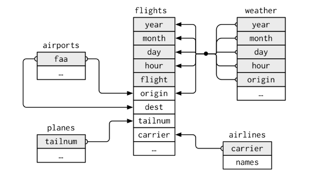

```r
library(nycflights13)
data(flights)
# select a set of 10 flights
flights <- flights %>%
  slice_sample(n = 10) %>%
  select(year:day, flight, origin, dest, carrier) # select subset of vars
flights
```

```
## # A tibble: 10 x 7
##     year month   day flight origin dest  carrier
##    <int> <int> <int>  <int> <chr>  <chr> <chr>
##  1  2013    12     8   3565 LGA    CLT   MQ
##  2  2013     3    20    269 JFK    SEA   AA
##  3  2013     4    28   4471 EWR    CAE   EV
##  4  2013     8    22      1 JFK    FLL   B6
##  5  2013     7     5    167 JFK    OAK   B6
##  6  2013     4     5   1588 EWR    LAX   UA
##  7  2013     3     2     27 JFK    SFO   VX
##  8  2013     5    28    347 LGA    ATL   FL
##  9  2013     3     2    415 JFK    MIA   AA
## 10  2013    11    30   1946 EWR    CLT   US
```

```r
# load the airlines list
data(airlines)
head(airlines)
```

```
## # A tibble: 6 x 2
##   carrier name
##   <chr>   <chr>
## 1 9E      Endeavor Air Inc.
## 2 AA      American Airlines Inc.
## 3 AS      Alaska Airlines Inc.
## 4 B6      JetBlue Airways
## 5 DL      Delta Air Lines Inc.
## 6 EV      ExpressJet Airlines Inc.
```

We will create just a simple task. The `flights` data frame contains all the information about the where and when of the flights, including delay information. However, all that interests us here is the `carrier` variable, which is the two-letter code for the airline name that you see on airline tickets. Most of the information in the data table is extraneous, so I will retain just the identifying information with the select command. Also, I am only going to use a 10 flight sample of the table, which we will select with `slice_sample()` a `dplyr` function that does exactly what it says: it samples either a number or proportion of a data table randomly.

## 4.2 Joining the Airline Name to `flights`

In the past and in other software systems, integrating the variables you need can be a major pain. In R, working with the set of *join* functions from `dplyr`, integrating variables from different databases is relatively easy.

You will notice that both `flights` and `airlines` have a variable `carrier` and that this value contains the same type of data in each table: the two-letter airline code. Joins work by adding the data in the second data frame to the data in the first by aligning the common key variable.[^7]

```r
# join the airline names to the flights
flights_mod <- flights %>%
  left_join(airlines, by = "carrier")
flights_mod[, 4:8]
```

```
## # A tibble: 10 x 5
##    flight origin dest  carrier name
##     <int> <chr>  <chr> <chr>   <chr>
##  1   3565 LGA    CLT   MQ      Envoy Air
##  2    269 JFK    SEA   AA      American Airlines Inc.
##  3   4471 EWR    CAE   EV      ExpressJet Airlines Inc.
##  4      1 JFK    FLL   B6      JetBlue Airways
##  5    167 JFK    OAK   B6      JetBlue Airways
##  6   1588 EWR    LAX   UA      United Air Lines Inc.
##  7     27 JFK    SFO   VX      Virgin America
##  8    347 LGA    ATL   FL      AirTran Airways Corporation
##  9    415 JFK    MIA   AA      American Airlines Inc.
## 10   1946 EWR    CLT   US      US Airways Inc.
```

R has joined the airline name to the flights table, which has made the table easier to read. In most cases, we are interested in making the tables easier to use for analysis, but the principle and the technique is the same.

## 4.3 Types of Joins

In this example, we created a `left_join()`. This means that the left hand (first) data table referred to would act as the anchor and the data from the second (or right-hand) table would be joined to it. This is the type of join you will most frequently use. However, there are other types.

A `left_join()` is one of the “mutating” joins, that is, it changes the left-hand data frame by adding one or more columns to it (one in this case). The `left_join()` function also retains all the cases in the left hand data table. If one of the `carrier` codes in the `flights` table had not had an equivalent entry in the `airlines` table, that case in the `flights` table would get a value of `NA` for the `name` field.

Other types of mutating joins include `right_join()`, in which the roles of left and right are simply reversed. There is also a `full_join()`, which keeps all the cases in both data tables and an `inner_join()`, which retains only those cases whose keys appear in both tables.

## 4.4 A Note on Keys

The key in this case was obvious, `carrier` as it was the only field that both tables had. To demonstrate how to tell the function what variable to use as a key, I used the argument `by = "carrier"`. **VSS** It helps to remember what you did and why you did it, to use the `by=` argument even if it not necessary.

If the two keys you need have different names in the two different tables, then you need to use a slightly different form of `by=`. If it is `a` in the left side table and `b` in the right table, then the argument will need the following form: `by = c("a" = "b")`. You will need to use the `c()` function altough it does appear somewhat awkward. Also, note all the quotation marks. The variable names need to be in quotes for this command.

# 5 Review – What Have We Learned?

We have covered a number of topics here, the breadth of which and the level of detail reflects the intensity of the effort we put into munging as opposed to the actual statistical analysis and modeling.

## 5.1 General Data Review and Manipulation

- summarytools::dfSummary()
  - provides a general overview of all variables and how many cases are valid or missing
- summarytools::freq()
  - table of frequencies of all values of categorical (ie., character and factor) variables
- summarytools::descr()
  - exploratory data analysis measures of numeric variables
- janitor::clean_names()
  - put all data frame names in machine interpretable form
- janitor::remove_constant()
  - remove all columns that only have a single value (besides NA)

## 5.2 The Pipe

- dplyr::%>%
  - operator that connects the result of one line of code to the first argument of the next line of code

## 5.3 Key Data Manipulation Functions of `dplyr`

- dplyr::filter()
  - work with a subset of cases (rows) of a data set based on a logical test
- dplyr::mutate()
  - change the value(s) of a variable or subset of a variable according to the expression within the `mutate` statement
- dplyr::select()
  - work with a subset of variables (columns) of a data set
- dplyr::xxx_join()
  - the various types of joins that bring data from a second table into the primary table

## 5.4 Support Functions for `dplyr`

- lubridate::dmy() (also myd(), ymd(), etc.)
  - translate a character string in the appropriate format to a date value
- forcats::fct_collapse()
  - reduce the number of levels of a factor to those necessary for analysis
- stringr::str_detect()
  - see if a sub-string exists within a larger string variable.

## 5.5 Base R

- base::factor()
  - turn a string variable into a factor

## 5.6 Data Pivoting with `tidyr` Functions

- tidyr::pivot_longer()
  - change database format from wide to long
[^1]: These names are taken from the vignette, **Overview of janitor functions**, from the `janitor` package. Firke, Sam. “Janitor: Simple Tools for Examining and Cleaning Dirty Data.” Manual, 2020. https://CRAN.R-project.org/package=janitor.
[^2]: This example is taken from Ismay, Chester, and Albert Young-Sun Kim. **Statistical Inference via Data Science: A ModernDive into R and the Tidyverse**. Chapman & Hall/Crc the r Series. Boca Raton: Taylor and Francis, 2019.
[^3]: While the term for this type of symbol is fairly commonly used in different computer languages, the original creator of the operator in R appears to be inspired by the Belgian surrealist painter, Rene Magritte, associating the word “pipe” with Magritte’s famous painting, “C’est ne pas une pipe”. Bache, Stefan Milton, and Hadley Wickham. “Magrittr: A Forward-Pipe Operator for r.” Manual, 2014. https://CRAN.R-project.org/package=magrittr.
[^4]: Although I said not to do this, I have not created a new data frame here. At the end of all of these transformations, I will show you how we join all the modifications together in one major tidying that will start with `einstein_soro` and create `einstein_soro_b`.
[^5]: The data is produced and published by Fundacao SEADE (Fundacao Sistema Estadual de Analise de Dados) daily and is available at https://github.com/seade-R/dados-covid-sp.
[^6]: You will notice that the structure of this data frame indicates that it is a `data.table`. This is a class of data distinct from the data frames and tibbles we have worked with so far. Its `fread()` function is very useful for reading and manipulating very large databases. The original file this small sample was drawn from is a “.csv” file of 121.3 megabytes with 731,000 records. We will not be dealing with `data.table` directly in this text, but keep it in mind as a valuable tool.
[^7]: In the first data table, this is referred to as the “primary” key and in the second, the “foreign” key. Foreign because it is part of the second data table, that is being used as a reference source.